# MBA on Bakery Store Transactional Data

The dataset consists of 21293 observations from a bakery. The data file contains four variables, Date, Time, Transaction ID and Item. Transaction ID ranges from 1 through 9684. However, there are some skipped numbers in Transaction IDs. Also, there are duplicated entries, as shown in observation # 2 and # 3. Besides, the Item contains "Adjustment", "NONE", and "Afternoon with the baker". While the entries of "Adjustment" and "NONE" are straight forward, "Afternoon with the baker" may be a real purchase.

```python
#Loading Libraries
import pandas as pd
import numpy as np
import seaborn as sns
import matplotlib.pyplot as plt
from mlxtend.preprocessing import TransactionEncoder
from mlxtend.frequent_patterns import apriori
from mlxtend.frequent_patterns import association_rules
```

[output not shown]

**Load Dataset**

```python
df=pd.read_csv('Bakery_Shop.csv')
```

**Check Head**

```python
df.head()
```

|  | Date | Time | Transaction | Item |
| --- | --- | --- | --- | --- |
| 0 | 2016-10-30 | 09:58:11 | 1 | Bread |
| 1 | 2016-10-30 | 10:05:34 | 2 | Scandinavian |
| 2 | 2016-10-30 | 10:05:34 | 2 | Scandinavian |
| 3 | 2016-10-30 | 10:07:57 | 3 | Hot chocolate |
| 4 | 2016-10-30 | 10:07:57 | 3 | Jam |

**Check Info**

```python
df.info()
```

```
<class 'pandas.core.frame.DataFrame'>
RangeIndex: 21293 entries, 0 to 21292
Data columns (total 4 columns):
 #   Column       Non-Null Count  Dtype
---  ------       --------------  -----
 0   Date         21293 non-null  object
 1   Time         21293 non-null  object
 2   Transaction  21293 non-null  int64
 3   Item         21293 non-null  object
dtypes: int64(1), object(3)
memory usage: 665.5+ KB
```

```python
df.describe().T
```

|  | count | mean | std | min | 25% | 50% | 75% | max |
| --- | --- | --- | --- | --- | --- | --- | --- | --- |
| Transaction | 21293.0 | 4951.990889 | 2787.7584 | 1.0 | 2548.0 | 5067.0 | 7329.0 | 9684.0 |

**Check Duplicates**

```python
df.duplicated().sum()
```

```
1653
```

```python
df['Item'] = df['Item'].str.lower()
```

```python
df
```

|  | Date | Time | Transaction | Item |
| --- | --- | --- | --- | --- |
| 0 | 2016-10-30 | 09:58:11 | 1 | bread |
| 1 | 2016-10-30 | 10:05:34 | 2 | scandinavian |
| 2 | 2016-10-30 | 10:05:34 | 2 | scandinavian |
| 3 | 2016-10-30 | 10:07:57 | 3 | hot chocolate |
| 4 | 2016-10-30 | 10:07:57 | 3 | jam |
| ... | ... | ... | ... | ... |
| 21288 | 2017-04-09 | 14:32:58 | 9682 | coffee |
| 21289 | 2017-04-09 | 14:32:58 | 9682 | tea |
| 21290 | 2017-04-09 | 14:57:06 | 9683 | coffee |
| 21291 | 2017-04-09 | 14:57:06 | 9683 | pastry |
| 21292 | 2017-04-09 | 15:04:24 | 9684 | smoothies |

21293 rows × 4 columns

```python
df = df.drop(df[df.Item == 'none'].index)
```

```python
df
```

|  | Date | Time | Transaction | Item |
| --- | --- | --- | --- | --- |
| 0 | 2016-10-30 | 09:58:11 | 1 | bread |
| 1 | 2016-10-30 | 10:05:34 | 2 | scandinavian |
| 2 | 2016-10-30 | 10:05:34 | 2 | scandinavian |
| 3 | 2016-10-30 | 10:07:57 | 3 | hot chocolate |
| 4 | 2016-10-30 | 10:07:57 | 3 | jam |
| ... | ... | ... | ... | ... |
| 21288 | 2017-04-09 | 14:32:58 | 9682 | coffee |
| 21289 | 2017-04-09 | 14:32:58 | 9682 | tea |
| 21290 | 2017-04-09 | 14:57:06 | 9683 | coffee |
| 21291 | 2017-04-09 | 14:57:06 | 9683 | pastry |
| 21292 | 2017-04-09 | 15:04:24 | 9684 | smoothies |

20507 rows × 4 columns

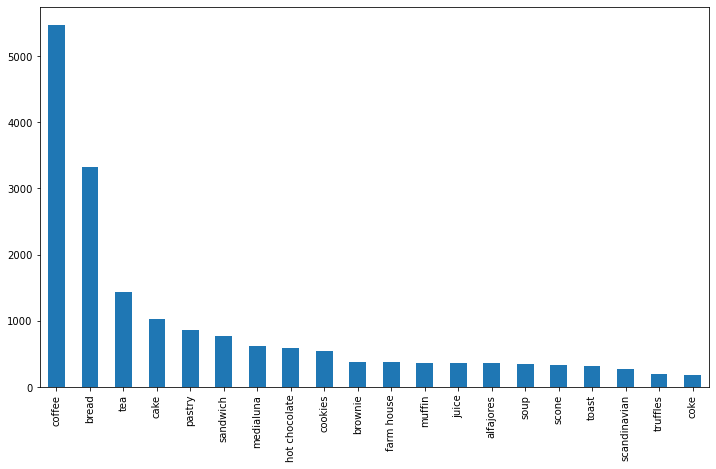

```python
df['Item'].value_counts().sort_values(ascending=False).head(20).plot(kind='bar',figsize=(12,7));
```

```python
basket=df.groupby(['Transaction', 'Item'])['Item'].count().unstack().reset_index().fillna(0).set_index('Transaction')
```

```python
basket.head()
```

| Item Transaction | adjustment | afternoon with the baker | alfajores | argentina night | art tray | bacon | baguette | bakewell | bare popcorn | basket | ... | the bart | the nomad | tiffin | toast | truffles | tshirt | valentine's card | vegan feast | vegan mincepie | victorian sponge |
| --- | --- | --- | --- | --- | --- | --- | --- | --- | --- | --- | --- | --- | --- | --- | --- | --- | --- | --- | --- | --- | --- |
| 1 | 0.0 | 0.0 | 0.0 | 0.0 | 0.0 | 0.0 | 0.0 | 0.0 | 0.0 | 0.0 | ... | 0.0 | 0.0 | 0.0 | 0.0 | 0.0 | 0.0 | 0.0 | 0.0 | 0.0 | 0.0 |
| 2 | 0.0 | 0.0 | 0.0 | 0.0 | 0.0 | 0.0 | 0.0 | 0.0 | 0.0 | 0.0 | ... | 0.0 | 0.0 | 0.0 | 0.0 | 0.0 | 0.0 | 0.0 | 0.0 | 0.0 | 0.0 |
| 3 | 0.0 | 0.0 | 0.0 | 0.0 | 0.0 | 0.0 | 0.0 | 0.0 | 0.0 | 0.0 | ... | 0.0 | 0.0 | 0.0 | 0.0 | 0.0 | 0.0 | 0.0 | 0.0 | 0.0 | 0.0 |
| 4 | 0.0 | 0.0 | 0.0 | 0.0 | 0.0 | 0.0 | 0.0 | 0.0 | 0.0 | 0.0 | ... | 0.0 | 0.0 | 0.0 | 0.0 | 0.0 | 0.0 | 0.0 | 0.0 | 0.0 | 0.0 |
| 5 | 0.0 | 0.0 | 0.0 | 0.0 | 0.0 | 0.0 | 0.0 | 0.0 | 0.0 | 0.0 | ... | 0.0 | 0.0 | 0.0 | 0.0 | 0.0 | 0.0 | 0.0 | 0.0 | 0.0 | 0.0 |

5 rows × 94 columns

```python
def encode_zero_one(x):
    if x <= 0:
        return 0
    if x >= 1:
        return 1
```

```python
basket=basket.applymap(encode_zero_one)
```

**Find the support for itemsets using Apriori**

```python
itemsets = apriori(basket, min_support = 0.01, use_colnames = True, low_memory=True)
itemsets
```

|  | support | itemsets |
| --- | --- | --- |
| 0 | 0.036344 | (alfajores) |
| 1 | 0.016059 | (baguette) |
| 2 | 0.327205 | (bread) |
| 3 | 0.040042 | (brownie) |
| 4 | 0.103856 | (cake) |
| ... | ... | ... |
| 56 | 0.023666 | (toast, coffee) |
| 57 | 0.014369 | (tea, sandwich) |
| 58 | 0.010037 | (cake, bread, coffee) |
| 59 | 0.011199 | (bread, coffee, pastry) |
| 60 | 0.010037 | (tea, cake, coffee) |

61 rows × 2 columns

**Visualizing the Support of itemsets**

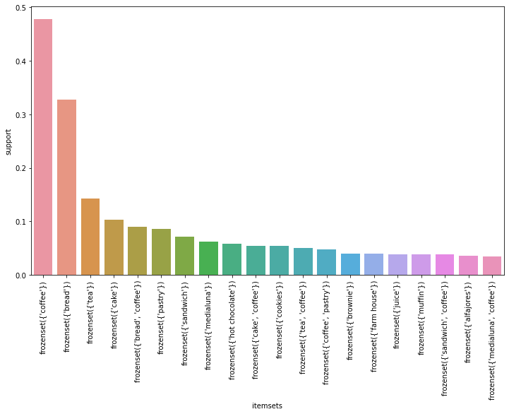

```python
plt.figure(figsize=(12,7))
sns.barplot(itemsets.sort_values('support',ascending=False).iloc[0:20,1],
            itemsets.sort_values('support',ascending=False).iloc[0:20,0])
plt.xticks(rotation=90)
plt.show()
```

**Check the rules using association_rules**

```python
basket = association_rules(itemsets, metric ="lift")
basket = basket.sort_values(['lift','confidence'], ascending =[False, False])
```

```python
basket.head(20)
```

|  | antecedents | consequents | antecedent support | consequent support | support | confidence | lift | leverage | conviction |
| --- | --- | --- | --- | --- | --- | --- | --- | --- | --- |
| 53 | (tea, coffee) | (cake) | 0.049868 | 0.103856 | 0.010037 | 0.201271 | 1.937977 | 0.004858 | 1.121962 |
| 56 | (cake) | (tea, coffee) | 0.103856 | 0.049868 | 0.010037 | 0.096643 | 1.937977 | 0.004858 | 1.051779 |
| 16 | (hot chocolate) | (cake) | 0.058320 | 0.103856 | 0.011410 | 0.195652 | 1.883874 | 0.005354 | 1.114125 |
| 17 | (cake) | (hot chocolate) | 0.103856 | 0.058320 | 0.011410 | 0.109868 | 1.883874 | 0.005354 | 1.057910 |
| 18 | (tea) | (cake) | 0.142631 | 0.103856 | 0.023772 | 0.166667 | 1.604781 | 0.008959 | 1.075372 |
| 19 | (cake) | (tea) | 0.103856 | 0.142631 | 0.023772 | 0.228891 | 1.604781 | 0.008959 | 1.111865 |
| 40 | (toast) | (coffee) | 0.033597 | 0.478394 | 0.023666 | 0.704403 | 1.472431 | 0.007593 | 1.764582 |
| 41 | (coffee) | (toast) | 0.478394 | 0.033597 | 0.023666 | 0.049470 | 1.472431 | 0.007593 | 1.016699 |
| 51 | (pastry) | (bread, coffee) | 0.086107 | 0.090016 | 0.011199 | 0.130061 | 1.444872 | 0.003448 | 1.046033 |
| 48 | (bread, coffee) | (pastry) | 0.090016 | 0.086107 | 0.011199 | 0.124413 | 1.444872 | 0.003448 | 1.043749 |
| 43 | (sandwich) | (tea) | 0.071844 | 0.142631 | 0.014369 | 0.200000 | 1.402222 | 0.004122 | 1.071712 |
| 42 | (tea) | (sandwich) | 0.142631 | 0.071844 | 0.014369 | 0.100741 | 1.402222 | 0.004122 | 1.032134 |
| 55 | (tea) | (cake, coffee) | 0.142631 | 0.054728 | 0.010037 | 0.070370 | 1.285822 | 0.002231 | 1.016827 |
| 54 | (cake, coffee) | (tea) | 0.054728 | 0.142631 | 0.010037 | 0.183398 | 1.285822 | 0.002231 | 1.049923 |
| 38 | (spanish brunch) | (coffee) | 0.018172 | 0.478394 | 0.010882 | 0.598837 | 1.251766 | 0.002189 | 1.300235 |
| 39 | (coffee) | (spanish brunch) | 0.478394 | 0.018172 | 0.010882 | 0.022747 | 1.251766 | 0.002189 | 1.004682 |
| 26 | (medialuna) | (coffee) | 0.061807 | 0.478394 | 0.035182 | 0.569231 | 1.189878 | 0.005614 | 1.210871 |
| 27 | (coffee) | (medialuna) | 0.478394 | 0.061807 | 0.035182 | 0.073542 | 1.189878 | 0.005614 | 1.012667 |
| 31 | (pastry) | (coffee) | 0.086107 | 0.478394 | 0.047544 | 0.552147 | 1.154168 | 0.006351 | 1.164682 |
| 30 | (coffee) | (pastry) | 0.478394 | 0.086107 | 0.047544 | 0.099382 | 1.154168 | 0.006351 | 1.014740 |

## Interpretations:

> The bakery store can provide some combo offer for tea,coffee and cake as they have good lift. The combination of hot chocolate & cake can also be thought of.

> A few discount offers on combos:

> ```
> - Toast with Coffee with 10% discount on breakfast combo
> - sandwich with tea combo with 5% discount
> ```

> You can design the discount offers and combos. The above discount % are just anonymous. Now, try to find some other transactional data like wholesale, retail, cosmetics, apparels etc and Try to build associations.

```
                                                 Happy Learning
```